# EDA Grocery Data Analysis

Nicole Rouleau

5/15/2025

# Introduction

Exploratory Data Analysis (EDA) is a type of an analysis used to gain a deeper knowledge of a dataset. This is done through both statistical and visualization means in order to find patterns and relationships within the data.

# Data

The data utilized here is the “Grocery Sales Dataset” created by Andrex Ibiza. This is a relational data set containing seven different interconnected tables on grocery sales, customers, locations, products, and employees.The data was gathered over a four-month period in early 2018 containing just under 100,000 unique customers and just over 6.5 million unique sales. While conducted in a short period it contains vast data across 100 cities (within the United States). Groceries have been placed into 11 different categories with there being a total of just over 450 unique products.

## Libraries

```r
#Data Manipulation
library(data.table)
library(dplyr)
library(lubridate)
library(tidyverse)
library(tools)

#Modeling
library(tidymodels)
library(xgboost)

#Plotting
library(factoextra)
library(viridis)
library(cluster)
library(scales)
```

## Import Data

```r
# Create directory
dir.create(path.expand("~/.kaggle"), showWarnings = FALSE)
file.copy("path/to/kaggle.json", path.expand("~/.kaggle/kaggle.json"))
Sys.chmod(path.expand("~/.kaggle/kaggle.json"), mode = "600")

# Dataset path
dataset <- "andrexibiza/grocery-sales-dataset"

# Download dataset to current working directory
system(paste("kaggle datasets download -d", dataset))

# Unzip the downloaded file
unzip("grocery-sales-dataset.zip", exdir = "grocery-sales-dataset")

# List extracted files
list.files()
```

```r
# Define the folder where the files are extracted
data_folder <- "grocery-sales-dataset"

# Get full file paths for all CSV files
file_paths <- list.files(data_folder, pattern = "\\.csv$", full.names = TRUE)

# Create clean variable names from file names
file_names <- file_path_sans_ext(basename(file_paths))
file_names <- make.names(file_names)  # ensures valid R names

# Read each file and assign it to the global environment
walk2(file_paths, file_names, ~ {
  message("Loading: ", .y)
  df <- fread(.x)
  assign(.y, df, envir = .GlobalEnv)
})

# Take a look at the data
head(sales)
head(categories)
head(customers)
head(cities)
head(employees)
head(products)
head(countries)
```

[output not shown]

- At first glance we can see that the Total Price is empty in the Sales data frame, we will need to add this in
- We can also note that the Products data frame ‘CategoryID’ does not align properly with the Catgeories data frame, we will remedy this as well

## Cleaning Data

```r
# Load correct map (manually created)
correct_products <- fread("corrected_products_grocery.csv")

# Join to fix CategoryID
products[, CategoryID := NULL]
setkey(products, ProductID)
setkey(correct_products, ProductID)
products <- correct_products[products]  # left join

# CategoryName for CategoryID 10 should be Household, not Snails, we can edit that here as well
categories$CategoryName[10] <- "Household"

# Rename columns for clarity between Employees, Customers. Cities, and Countries
employees <- employees %>%
  rename(
   EmployeeFirstName = FirstName,
   EmployeeMI = MiddleInitial,
   EmployeeLastName = LastName,
   EmployeeBD = BirthDate,
   EmployeeGender = Gender,
   EmployeeHireDate = HireDate,
   EmployeeCityID = CityID,
  )

customers <- customers %>%
  rename(
    CustomerFirstName = FirstName,
    CustomerMI = MiddleInitial,
    CustomerLastName = LastName,
    CustomerAddress = Address,
    CustomerCityID = CityID,
  )

cities <- cities %>%
  rename(CityID = CityID, CityName = CityName)

countries <- countries %>%
  rename(CountryID = CountryID, CountryName = CountryName)
```

Let’s combine our data frames into one usable table.

```r
# Join Cities & Countries
cities_full <- cities %>%
  left_join(countries, by = "CountryID")

# Join employee location
employees_full <- employees %>%
  left_join(cities_full, by = c("EmployeeCityID" = "CityID")) %>%
  rename(
    EmployeeCityName = CityName,
    EmployeeCountryName = CountryName,
    EmployeeCountryCode = CountryCode,
    EmployeeZipcode = Zipcode,
    EmployeeCountryID = CountryID
  )

# Join customer location
customers_full <- customers %>%
  left_join(cities_full, by = c("CustomerCityID" = "CityID")) %>%
  rename(
    CustomerCityName = CityName,
    CustomerCountryName = CountryName,
    CustomerCountryCode = CountryCode,
    CustomerZipcode = Zipcode,
    CustomerCountryID = CountryID
  )

# Final Join
sales_full <- sales %>%
  rename(EmployeeID = SalesPersonID) %>%
  left_join(employees_full, by = "EmployeeID") %>%
  left_join(products,       by = "ProductID") %>%
  left_join(customers_full, by = "CustomerID") %>%
  left_join(categories,     by = "CategoryID")

# Utilize the Price set in the Products data frame to create the missing Total Price and replace the zeros while also taking into account the Discount (we will assume the Discount is per item here and not per transaction, since it is not stated)
sales_full[, TotalPrice := Quantity * Price - Quantity * Discount]

#Clean up the date to a Y/M/D format
sales_full$SalesDate <- as.Date(sales_full$SalesDate, format = "%Y-%m-%d")
sales_full$ModifyDate <- as.Date(sales_full$ModifyDate, format = "%Y-%m-%d")
sales_full$EmployeeBD <- as.Date(sales_full$EmployeeBD, format = "%Y-%m-%d")
sales_full$EmployeeHireDate <- as.Date(sales_full$EmployeeHireDate, format = "%Y-%m-%d")

head(sales_full, 10)
```

```
##     SalesID EmployeeID CustomerID ProductID Quantity Discount TotalPrice
##       <int>      <int>      <int>     <int>    <int>    <num>      <num>
##  1:       1          6      27039       381        7      0.0   309.6359
##  2:       2         16      25011        61        7      0.0   437.8220
##  3:       3         13      94024        23       24      0.0  1896.4416
##  4:       4          8      73966       176       19      0.2  1541.2173
##  5:       5         10      32653       310        9      0.0   719.8020
##  6:       6         13      28663       413        8      0.0   763.2520
##  7:       7         14      46674       370       12      0.0   262.5672
##  8:       8          3      12687       287        4      0.2   230.0360
##  9:       9         16      89009       124       23      0.0   420.6493
## 10:      10         22      65017       346       17      0.2   288.8538
##      SalesDate    TransactionNumber EmployeeFirstName EmployeeMI
##         <Date>               <char>            <char>     <char>
##  1: 2018-02-05 FQL4S94E4ME1EZFTG42G             Holly          E
```

[output cut: 93 more lines]

# Analysis

## 1. Descriptive Analytics

```r
# Total Sales by Category
sales_desc_cat <- sales_full[, .(total_sales_by_category_desc = sum(TotalPrice)),
                             by = CategoryName][order(-total_sales_by_category_desc)]
head(sales_desc_cat)
```

```
##    CategoryName total_sales_by_category_desc
##          <char>                        <num>
## 1:      Produce                   1180218369
## 2:    Beverages                    910978636
## 3:        Grain                    474108026
## 4:         Meat                    422054067
## 5:    Household                    399066719
## 6:  Confections                    348663651
```

```r
sales_asc_cat <- sales_full[, .(total_sales_by_category_asc = sum(TotalPrice)),
                             by = CategoryName][order(total_sales_by_category_asc)]
head(sales_asc_cat)
```

```
##    CategoryName total_sales_by_category_asc
##          <char>                       <num>
## 1:      Cereals                    20123639
## 2:      Poultry                    69911738
## 3:   Shell fish                   127561973
## 4:      Seafood                   172553843
## 5:        Dairy                   338384188
## 6:  Confections                   348663651
```

```r
# Total Sales by Product
sales_desc_product <- sales_full[, .(total_sales_by_product_desc = sum(TotalPrice)),
                             by = ProductName][order(-total_sales_by_product_desc)]
head(sales_desc_product)
```

```
##                   ProductName total_sales_by_product_desc
##                        <char>                       <num>
## 1: Bread - Calabrese Baguette                    19443221
## 2:             Shrimp - 31/40                    19293561
## 3:                  Tia Maria                    19271038
## 4:      Puree - Passion Fruit                    19261178
## 5:          Zucchini - Yellow                    19116873
## 6:              Vanilla Beans                    19100309
```

```r
sales_asc_product <- sales_full[, .(total_sales_by_product_asc = sum(TotalPrice)),
                             by = ProductName][order(total_sales_by_product_asc)]
head(sales_asc_product)
```

```
##                      ProductName total_sales_by_product_asc
##                           <char>                      <num>
## 1: Bread Crumbs - Japanese Style                   3074.208
## 2:             Apricots - Halves                  67266.476
## 3: Pastry - Raisin Muffin - Mini                  77735.967
## 4:    Sole - Dover, Whole, Fresh                 128075.483
## 5:          Bread Fig And Almond                 223906.943
## 6:       Crab - Dungeness, Whole                 235851.964
```

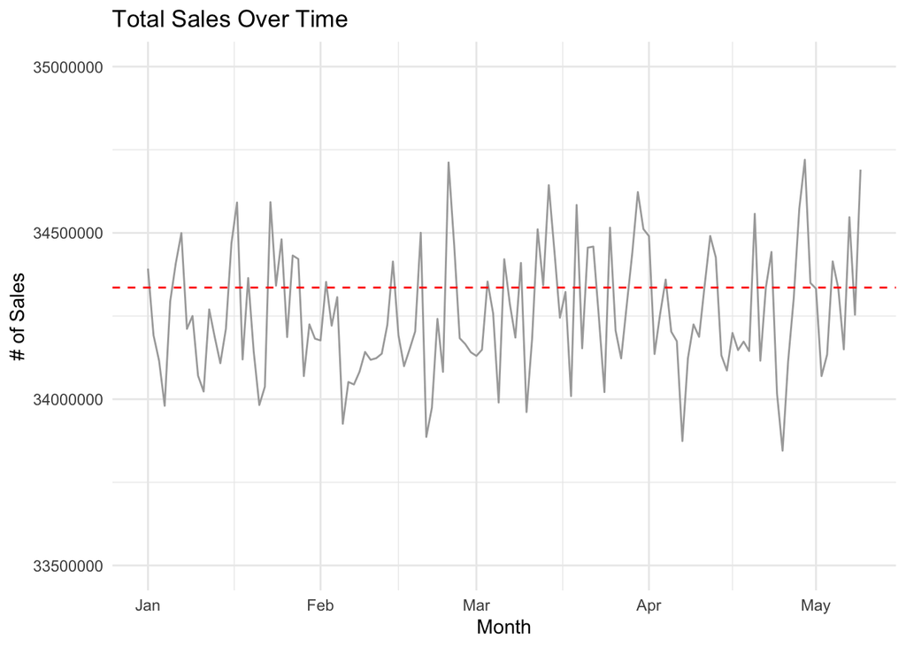

```r
# Total Sales over the total 4 months
sales_full %>%
  group_by(SalesDate) %>%
  summarise(daily_sales = sum(TotalPrice)) %>%
  ggplot(aes(SalesDate, daily_sales)) +
  geom_line(color = "darkgrey") +
  geom_hline(aes(yintercept = mean(daily_sales)), linetype = "dashed", color = "red") +
  ylim(3.35e+07, 3.5e+07) +
  labs(title = "Total Sales Over Time",
       x = "Month", y = "# of Sales") +
  theme_minimal()
```

Insights:

- Produce is the highest selling category, followed by Beverages and Grain
- Cereals is the lowest selling category, followed Poultry and Shellfish
- Bread (Calabrese Baguette) is the highest selling product, followed by Shrimp (31/40) and Tia Maria (a beverage)
  - This is interesting as shrimp is high selling in products but overall shellfish is one of the lowest selling categories
  - Grain is a high selling category, this lines up with Bread being a top selling product
- Bread Crumbs (Japanese Style) is the lowest selling product, followed by Apricot (Halves) and Pastry (Raisin Muffin Mini).
- Overall sales seem to be fairly even throughout the January to the start of May. While there are dips and spikes we can see the red-dashed mean line is fairly even between it all. There was little sale variation over the 4 months, with January looking to have the least variation.

## 2. Customer-Sales Behavior

```r
# Total spend per customer
total_spend <- sales_full[, .(customer_total_spend = sum(TotalPrice, na.rm = TRUE)),
                             by = CustomerID][order(-customer_total_spend)]
head(total_spend)
```

```
##    CustomerID customer_total_spend
##         <int>                <num>
## 1:      94800             134328.2
## 2:      95972             127759.7
## 3:      95048             126207.2
## 4:      97863             125849.0
## 5:      95157             124593.1
## 6:      94138             124470.5
```

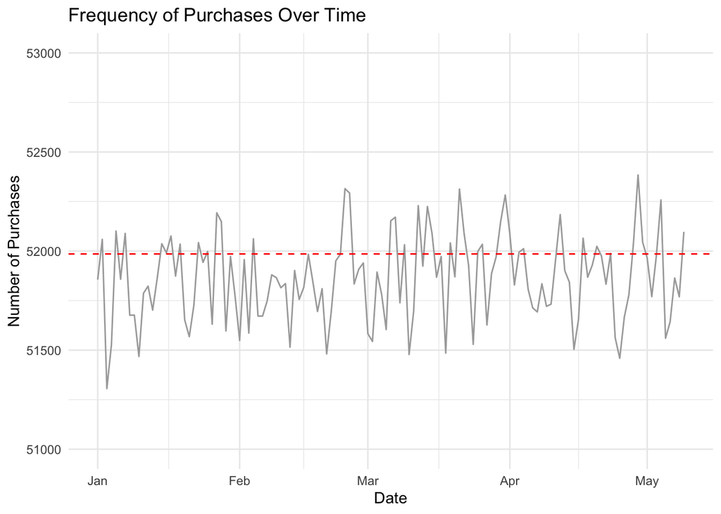

```r
# Frequency of purchases
sales_full %>%
  group_by(SalesDate) %>%
  summarise(purchase_count = n()) %>%
  ggplot(aes(SalesDate, purchase_count)) +
  geom_line(color = "darkgrey") +
  geom_hline(aes(yintercept = mean(purchase_count)), linetype = "dashed", color = "red") +
  ylim(51000, 53000) +
  labs(title = "Frequency of Purchases Over Time",
       x = "Date", y = "Number of Purchases") +
  theme_minimal()
```

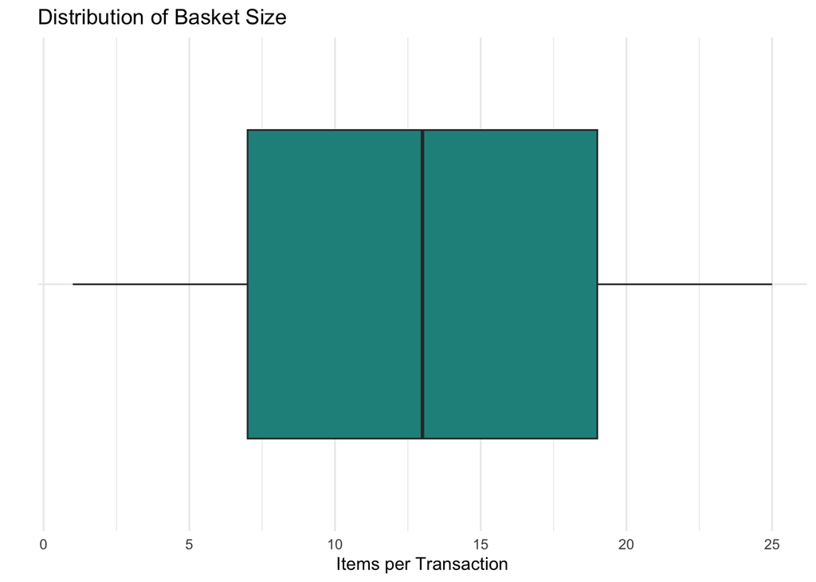

```r
# Calculate Basket Size Per Transaction
basket_size <- sales_full[, .(items_per_transaction = sum(Quantity, na.rm = TRUE)),
                             by = SalesID]

# Boxplot
ggplot(basket_size, aes(x = "", y = items_per_transaction)) +
  geom_boxplot(fill = "#21908CFF") +
  coord_flip() +
  labs(
    title = "Distribution of Basket Size",
    y = "Items per Transaction",
    x = ""
  ) +
  theme_minimal()
```

## 3. Customer-Product Behavior

```r
# How much each customer spent on each product
# Combined grouped summary
customer_product_summary <- sales_full[
  , .(
    total_quantity = sum(Quantity, na.rm = TRUE),
    total_spent = sum(TotalPrice, na.rm = TRUE),
    n_purchases = .N
  ),
  by = .(CustomerID, ProductID, ProductName)
]

# Sort once by spend
customer_product_summary1 <- customer_product_summary %>%
  arrange(desc(total_spent))

# Sort once by quantity
customer_product_summary2 <- customer_product_summary %>%
  arrange(desc(total_quantity))

# Preview
head(customer_product_summary1)
```

```
##    CustomerID ProductID              ProductName total_quantity total_spent
##         <int>     <int>                   <char>          <int>       <num>
## 1:      79044       284      Beer - Rickards Red            105    9812.124
## 2:      97322       319   Towels - Paper / Kraft            125    9697.438
## 3:      98231       151 Mushrooms - Black, Dried            100    9353.630
## 4:      86852       416            Baking Powder            110    9307.793
## 5:      95584       159         Eggplant - Asian            100    9208.030
## 6:      97102       395             Juice - Lime            100    9178.330
##    n_purchases
##          <int>
## 1:           5
## 2:           5
## 3:           4
## 4:           5
## 5:           4
## 6:           4
```

```r
head(customer_product_summary2)
```

```
##    CustomerID ProductID                ProductName total_quantity total_spent
##         <int>     <int>                     <char>          <int>       <num>
## 1:      97322       319     Towels - Paper / Kraft            125    9697.438
## 2:      89808       172               Sherry - Dry            115    1840.149
## 3:      90310       322           Onions - Vidalia            115    3015.829
## 4:      86852       416              Baking Powder            110    9307.793
## 5:      79044       284        Beer - Rickards Red            105    9812.124
## 6:      98434        67 Wine - Sogrape Mateus Rose            100     375.550
##    n_purchases
##          <int>
## 1:           5
## 2:           5
## 3:           5
## 4:           5
## 5:           5
## 6:           4
```

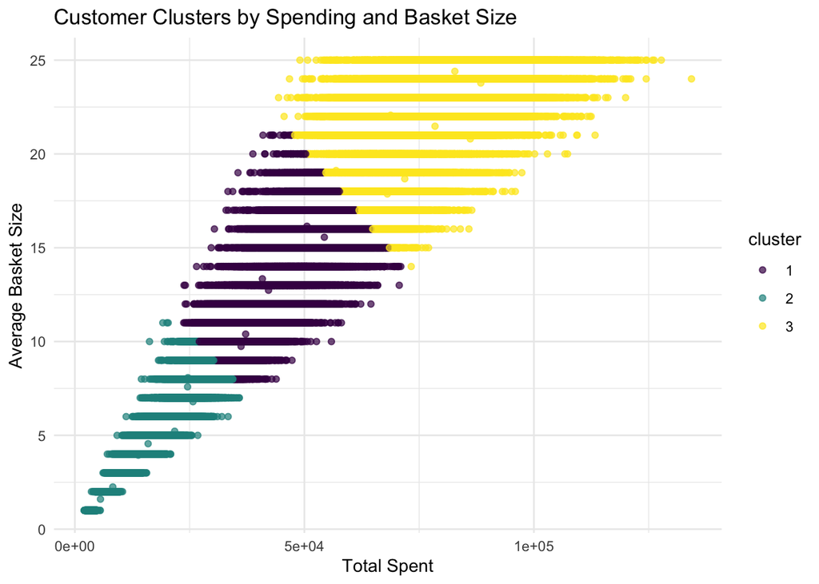

```r
# Cluster Customers by Spending
# Customer Summary
customer_summary <- sales_full[
  , .(
    total_spent = sum(TotalPrice, na.rm = TRUE),
    avg_basket_size = mean(Quantity, na.rm = TRUE),
    n_transactions = n_distinct(SalesID)
  ),
  by = .(CustomerID)
]

# Scale data
customer_scaled <- scale(customer_summary[, .(total_spent, avg_basket_size)])

# K-means
set.seed(123)
kmeans_result <- kmeans(customer_scaled, centers = 3)
customer_summary$cluster <- as.factor(kmeans_result$cluster)

# Visualize
ggplot(customer_summary, aes(x = total_spent, y = avg_basket_size, color = cluster)) +
  geom_point(alpha = 0.7) +
  scale_color_viridis_d(option = "D") +
  labs (
    title = "Customer Clusters by Spending and Basket Size",
    x = "Total Spent",
    y = "Average Basket Size"
  ) +
  theme_minimal()
```

```r
# Analyze Cluster
customer_summary %>%
  group_by(cluster) %>%
  summarise(
    avg_spent = mean(total_spent),
    avg_basket = mean(avg_basket_size),
    count = n()
  )
```

```
## # A tibble: 3 × 4
##   cluster avg_spent avg_basket count
##   <fct>       <dbl>      <dbl> <int>
## 1 1          45137.      13.2  33327
## 2 2          16205.       4.75 33381
## 3 3          75455.      21.3  32051
```

Insights:

- Customers are spending the most on Beer, Paper Towels and Mushrooms
  - Beverages and produce is are top selling categories, this aligns well
- Customers are purchasing the most of Paper Towels, Sherry, and Onions
  - We can see that customers who purchase the highest quantity of items are not necessarily the highest spenders but generally the more quantity or larger basket size, the higher the total spend.
    - Our highest sales categories we see again with beverages and produce

## 4. Salesperson Effectiveness

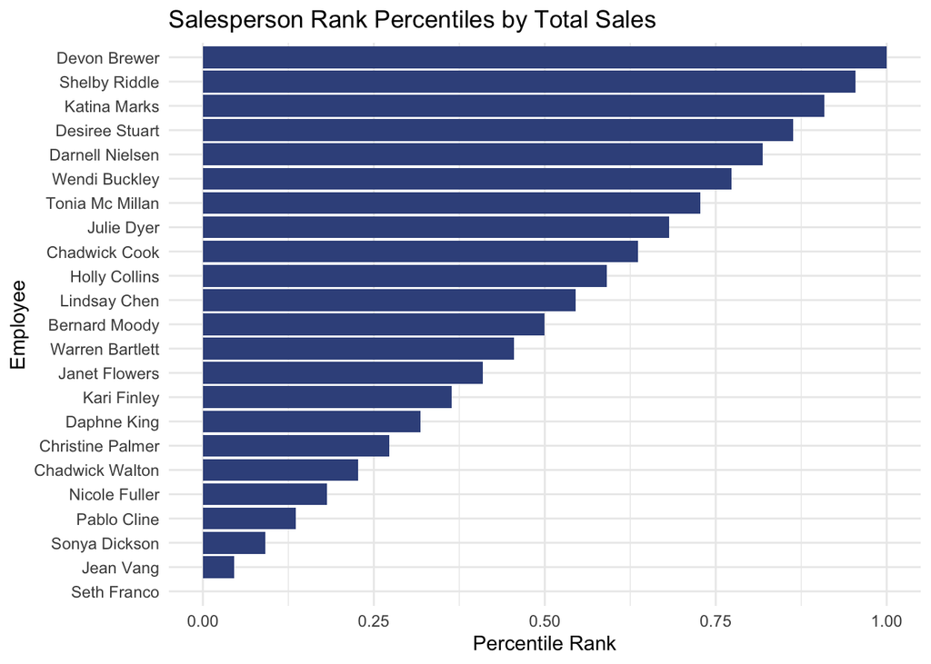

```r
# Sales by Employees Summary
sales_by_employee <- sales_full[
  , .(
    total_sales = sum(TotalPrice, na.rm = TRUE),
    total_quantity = sum(Quantity, na.rm = TRUE),
    num_transactions = .N,
    avg_discount = mean(Discount, na.rm = TRUE),
    unique_customers = uniqueN(CustomerID),
    unique_products = uniqueN(ProductID),
    avg_transaction_value = mean(TotalPrice, na.rm = TRUE)
  ),
  by = .(EmployeeID, EmployeeFirstName, EmployeeLastName)
][order(-total_sales)]
head(sales_by_employee)

# Monthly Sales per Employee
# Create a SalesMonth column
sales_full[, SalesMonth := format(as.Date(SalesDate), "%Y-%m")]

# Summarize monthly sales per employee
monthly_performance <- sales_full[
  , .(monthly_sales = sum(TotalPrice, na.rm = TRUE)),
  by = .(EmployeeID, SalesMonth, EmployeeFirstName, EmployeeLastName)
]
head(monthly_performance)

# Top Employees
sales_by_employee <- sales_by_employee %>%
  arrange(desc(total_sales)) %>%
  mutate(rank = row_number(),
         percentile = percent_rank(total_sales))

ggplot(sales_by_employee, aes(x = reorder(paste(EmployeeFirstName, EmployeeLastName), total_sales), y = percentile)) +
  geom_col(fill = "#3B528BFF") +
  coord_flip() +
  labs(
    title = "Salesperson Rank Percentiles by Total Sales",
    x = "Employee",
    y = "Percentile Rank"
  ) +
  theme_minimal()
```

[output not shown]

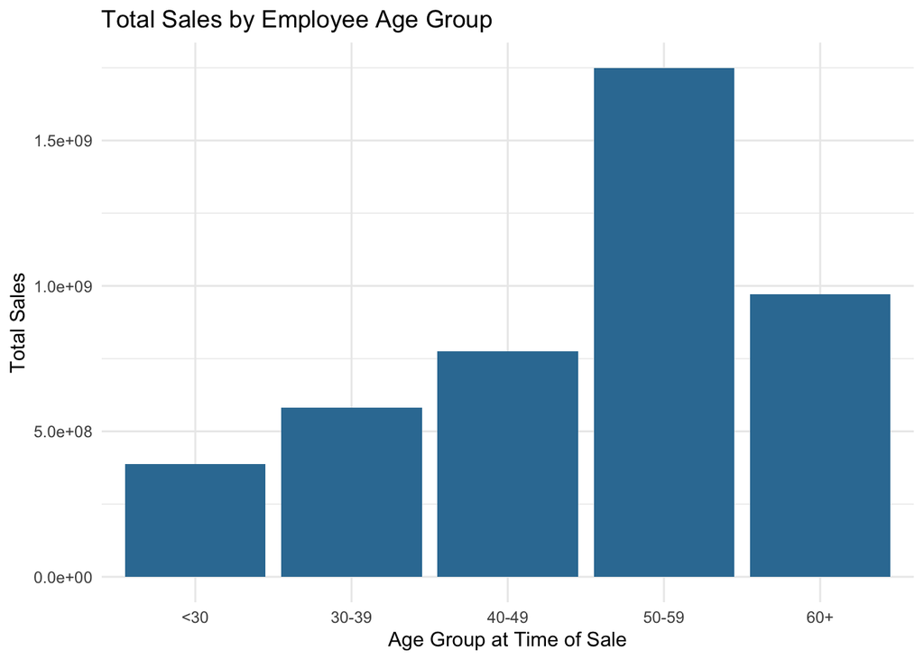

```r
# Performance by City
employee_city_performance <- sales_full[
  , .(city_sales = sum(TotalPrice, na.rm = TRUE)),
  by = .(EmployeeID, EmployeeCityID, EmployeeCityName)
]
head(employee_city_performance)

# Performance by Age & Tenure
sales_full[, AgeAtSale := as.integer(floor((SalesDate - EmployeeBD) / 365.25))]
sales_full[, TenureAtSale := as.integer(floor((SalesDate - EmployeeHireDate) / 365.25))]

employee_performance <- sales_full[
  , .(
    total_sales = sum(TotalPrice, na.rm = TRUE),
    total_quantity = sum(Quantity, na.rm = TRUE),
    n_transactions = uniqueN(TransactionNumber),
    avg_discount = mean(Discount, na.rm = TRUE),
    unique_customers = uniqueN(CustomerID),
    unique_products = uniqueN(ProductID),
    avg_transaction_value = mean(TotalPrice, na.rm = TRUE),
    avg_age_at_sale = mean(AgeAtSale, na.rm = TRUE),
    avg_tenure_at_sale = mean(TenureAtSale, na.rm = TRUE)
  ),
  by = .(EmployeeID, EmployeeFirstName, EmployeeLastName)
][order(-total_sales)]
head(employee_performance)

employee_performance[, AgeGroup := cut(
  avg_age_at_sale, breaks = c(0, 29, 39, 49, 59, Inf),
  labels = c("<30", "30-39", "40-49", "50-59", "60+"),
  right = FALSE
)]

employee_performance[, TenureGroup := cut(
  avg_tenure_at_sale, breaks = c(0, 2, 4, 6, 8, 10, Inf),
  labels = c("<2 yrs", "2-4 yrs", "4-6 yrs", "6-8 yrs", "8-10 yrs", "10+ yrs"),
  right = FALSE
)]

ggplot(employee_performance, aes(x = AgeGroup, y = total_sales)) +
  geom_col(fill = "#357BA2FF") +
  labs(
    title = "Total Sales by Employee Age Group",
    x = "Age Group at Time of Sale",
    y = "Total Sales"
  ) +
  theme_minimal()
```

[output not shown]

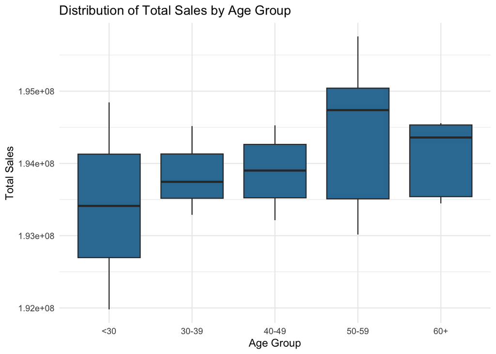

```r
ggplot(employee_performance, aes(x = AgeGroup, y = total_sales)) +
  geom_boxplot(fill = "#357BA2FF") +
  labs(
    title = "Distribution of Total Sales by Age Group",
    x = "Age Group",
    y = "Total Sales"
  ) +
  theme_minimal()
```

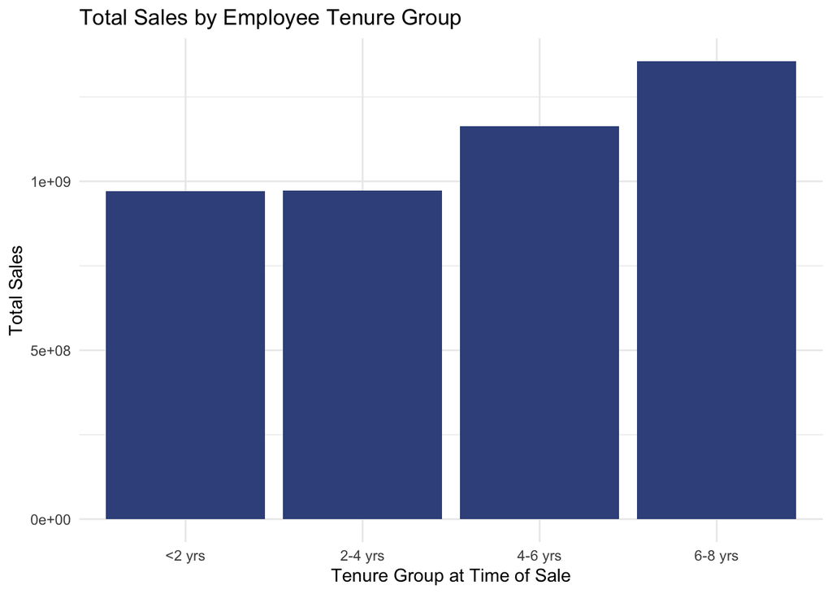

```r
ggplot(employee_performance, aes(x = TenureGroup, y = total_sales)) +
  geom_col(fill = "#3B528BFF") +
  labs(
    title = "Total Sales by Employee Tenure Group",
    x = "Tenure Group at Time of Sale",
    y = "Total Sales"
  ) +
  theme_minimal()
```

Insights:

- Devon Brewer, Shelby Riddle, and Katina Marks made the most sales giving out average discounts of .029 with an average transaction value of about $660
- Ranking the salespeople, we see that Devon Brewer is bringing in the most with Seth Franco selling the least
  - Bernard Moody is doing better than 50% his coworkers and 50% worse than the rest
- The employees were from all different cities. With Baltimore, Tuscon and Anchorage leading in sales
- Age seems to play factor, with those in their 50s making much more sales than their peers
  - When looking at the boxplot it seems that even the mean of the data shifts quite a bit with those under 30 making well below their peers and those in the 50s age range doing much better
- Looking at tenure, not surprisingly, the more tenured the employee, the stronger their individual sales are

## 5. Geographic Trends

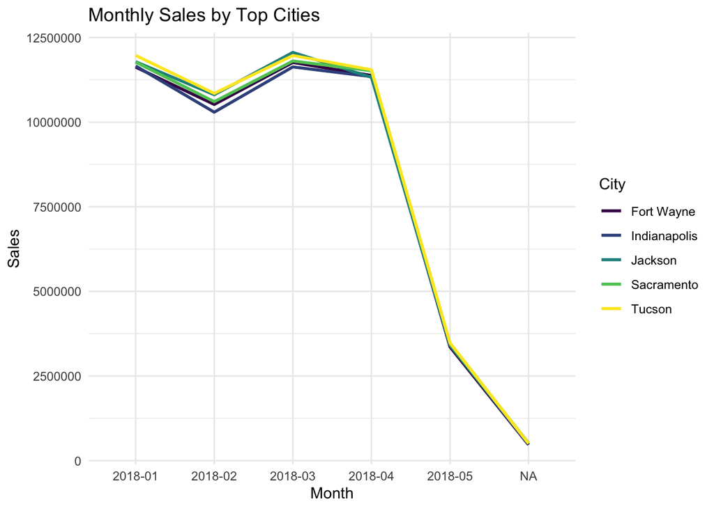

```r
# Customer Sales by City
sales_by_city <- sales_full [
  , .(city_sales = sum(TotalPrice)),
  by = .(CustomerCityID, CustomerCityName)][order(-city_sales)]
head(sales_by_city)

# Sales per customer
sales_per_customer <- sales_full[
  , .(total_sales = sum(TotalPrice), num_customers = uniqueN(CustomerID)),
  by = .(CustomerCityID, CustomerCityName)
][
  , sales_per_customer := total_sales / num_customers
][order(-sales_per_customer)]
head(sales_per_customer)

# Trends Over Time
monthly_city_sales <- sales_full[
  , .(monthly_sales = sum(TotalPrice)),
  by = .(CustomerCityName, SalesMonth)
]

top_cities <- monthly_city_sales[, .(total = sum(monthly_sales)), by = CustomerCityName][
  order(-total)
][1:5, CustomerCityName]
filtered_data <- monthly_city_sales[CustomerCityName %in% top_cities]

ggplot(filtered_data, aes(x = SalesMonth, y = monthly_sales, color = CustomerCityName, group = CustomerCityName)) +
  geom_line(linewidth = 1) +
  scale_color_viridis_d(option = "D") +
  labs(title = "Monthly Sales by Top Cities", x = "Month", y = "Sales", color = "City") +
  theme_minimal() +
  theme(legend.position = "right")
```

[output not shown]

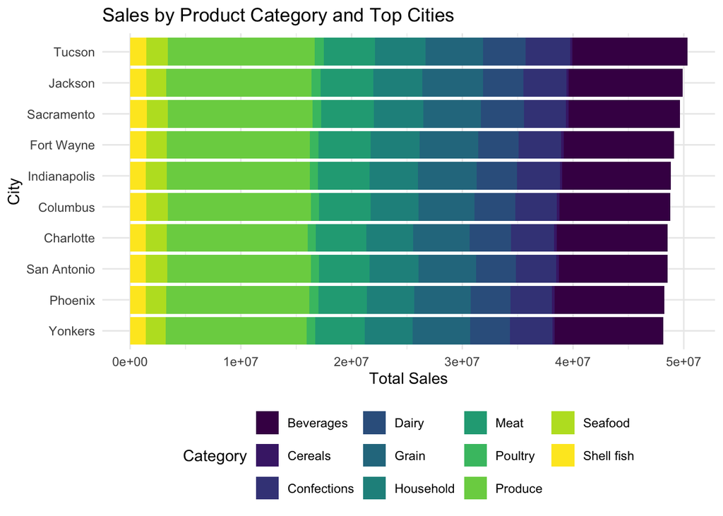

```r
# Customer Density v Sales
customer_density_sales <- sales_full[
  , .(
    total_sales = sum(TotalPrice),
    unique_customers = uniqueN(CustomerID),
    avg_sales_per_customer = sum(TotalPrice) / uniqueN(CustomerID)
  ),
  by = .(CustomerCityName)][order(-unique_customers)]
head(customer_density_sales)

# Average Transaction Value by City
transaction_value <- sales_full[
  , .(avg_transaction_value = mean(TotalPrice, na.rm = TRUE)),
  by = CustomerCityName][order(-avg_transaction_value)]
head(transaction_value)

# Basket Size by City
basket_size_city <- sales_full[
  , .(avg_basket_size = mean(Quantity, na.rm = TRUE)),
  by = CustomerCityName][order(-avg_basket_size)]
head(basket_size_city)

# Product Category Sales by City
category_by_city <- sales_full[
  , .(total_sales = sum(TotalPrice)),
  by = .(CustomerCityName, CategoryName)][order(-total_sales)]

top_cities <- category_by_city[, .(city_sales = sum(total_sales)), by = CustomerCityName][
  order(-city_sales)
][1:10, CustomerCityName]

category_by_city_filtered <- category_by_city[CustomerCityName %in% top_cities]

ggplot(category_by_city_filtered, aes(x = reorder(CustomerCityName, total_sales), y = total_sales, fill = CategoryName)) +
  geom_col(position = "stack") +
  coord_flip() +
  scale_fill_viridis_d(option = "D", name = "Category") +
  labs(
    title = "Sales by Product Category and Top Cities",
    x = "City",
    y = "Total Sales"
  ) +
  theme_minimal() +
  theme(legend.position = "bottom")
```

[output not shown]

## 6. Category/ Product Analysis

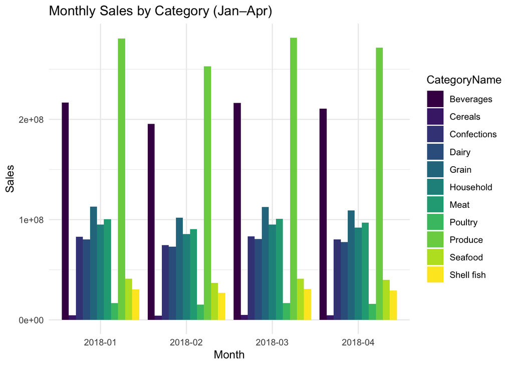

```r
sales_full[, SalesMonth := format(SalesDate, "%Y-%m")]

# Products Monthly Trends
category_monthly <- sales_full[
  , .(monthly_sales = sum(TotalPrice)),
  by = .(CategoryName, SalesMonth)
]

ggplot(category_monthly, aes(x = SalesMonth, y = monthly_sales, fill = CategoryName)) +
  geom_col(position = "dodge") +
  scale_x_discrete(limits = c("2018-01", "2018-02", "2018-03", "2018-04")) +
  labs(title = "Monthly Sales by Category (Jan–Apr)", x = "Month", y = "Sales") +
  theme_minimal() +
  scale_fill_viridis_d()
```

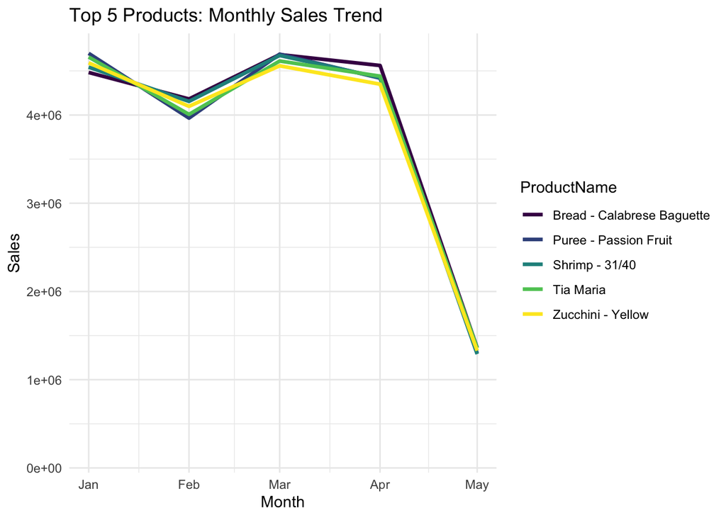

```r
sales_full[, SalesMonth := as.Date(paste0(SalesMonth, "-01"))]
# Top Products Trajectory
top_products <- sales_full[
  , .(total_sales = sum(TotalPrice)),
  by = ProductName
][order(-total_sales)][1:5, ProductName]|> as.character()

product_monthly <- sales_full[
  ProductName %in% top_products,
  .(monthly_sales = sum(TotalPrice)),
  by = .(ProductName, SalesMonth)
]

ggplot(product_monthly, aes(x = SalesMonth, y = monthly_sales, color = ProductName)) +
  geom_line(linewidth = 1.2) +
  scale_color_viridis_d() +
  labs(title = "Top 5 Products: Monthly Sales Trend", x = "Month", y = "Sales") +
  theme_minimal()
```

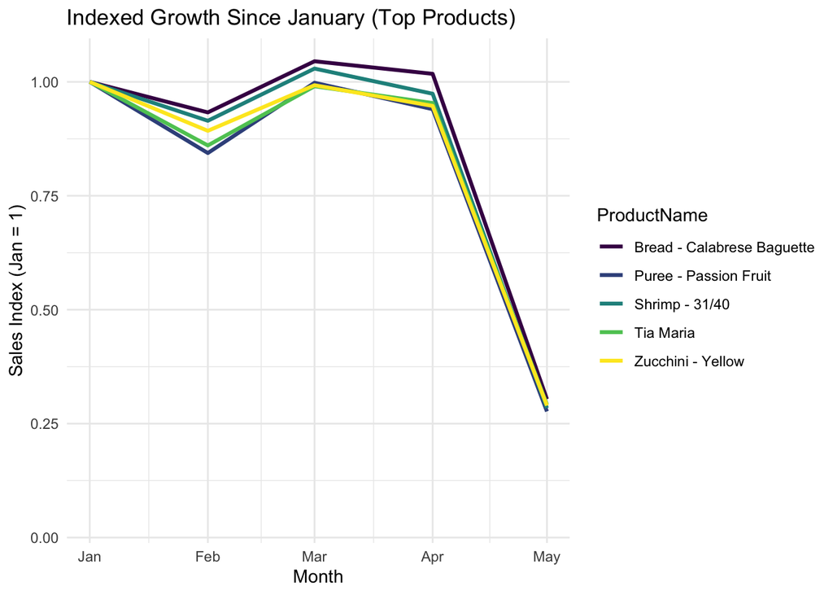

```r
# Normalize to Baseline
product_monthly <- product_monthly[order(SalesMonth)]
product_monthly[, baseline := monthly_sales[1], by = ProductName]
product_monthly <- product_monthly[!is.na(baseline) & baseline != 0]
product_monthly[, index := monthly_sales / baseline]

ggplot(product_monthly, aes(x = SalesMonth, y = index, color = ProductName)) +
  geom_line(linewidth = 1.1) +
  scale_color_viridis_d() +
  labs(title = "Indexed Growth Since January (Top Products)", y = "Sales Index (Jan = 1)", x = "Month") +
  theme_minimal()
```

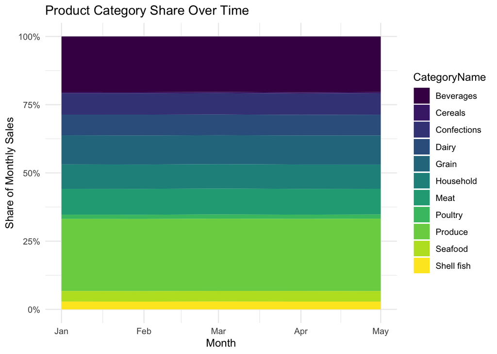

```r
# Category Monthly Trends
monthly_category_mix <- sales_full[
  , .(monthly_sales = sum(TotalPrice, na.rm = TRUE)),
  by = .(SalesMonth, CategoryName)
]

ggplot(monthly_category_mix, aes(x = SalesMonth, y = monthly_sales, fill = CategoryName)) +
  geom_area(position = "fill") +
  scale_fill_viridis_d() +
  labs(title = "Product Category Share Over Time", y = "Share of Monthly Sales", x = "Month") +
  scale_y_continuous(labels = scales::percent) +
  theme_minimal()
```

```r
# Top product per Month
top_by_month <- sales_full[
  , .(monthly_sales = sum(TotalPrice, na.rm = TRUE)),
  by = .(ProductName, SalesMonth)
][
  , .SD[which.max(monthly_sales)], by = SalesMonth
][order(-monthly_sales)]

head(top_by_month)
```

[output not shown]

Insights:

- There is some variation over months with category popularity, but generally, produce stays the most in demand with beverages coming in second
  - At no point do any two categories change positions
- All top products follow the same sales trends we have seen previously from January through April
- Bread (Calabrese Baguette) shows the most relative growth to it’s competitors while still falling in the same trend line
- With very few dips, category share of sales over January-April stayed very consistent
- Passion Fruit Puree was the top product for the months of January and March while Bread (Calabrese Baguette) was the top product the rest of the months

## 7. Forecasting

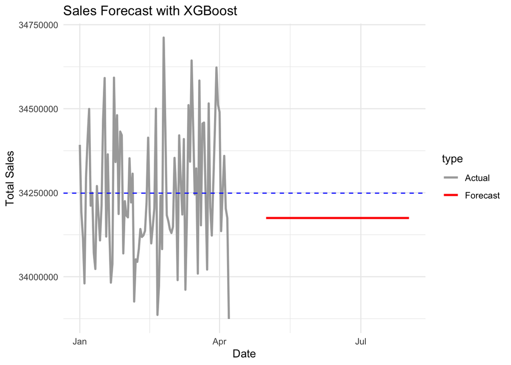

```r
# Future Sales
# Prep Data
sales_full <- as.data.table(sales_full)
sales_full[, SalesDate := as.Date(SalesDate)]
sales_full[, SalesMonth := floor_date(SalesDate, "month")]
sales_full[, DayOfWeek := lubridate::wday(SalesDate, label = TRUE)]
sales_full[, IsWeekend := ifelse(DayOfWeek %in% c("Sat", "Sun"), 1, 0)]

# Aggregate by date
daily_sales <- sales_full[, .(
  total_sales = sum(TotalPrice),
  num_sales = .N,
  city = first(CustomerCityName),
  category = first(CategoryName),
  day_of_week = first(DayOfWeek),
  is_weekend = first(IsWeekend)
), by = SalesDate]

# Convert to tibble
sales_tbl <- as_tibble(daily_sales)

sales_tbl <- sales_tbl %>%
  arrange(SalesDate) %>%
  mutate(MonthNum = as.integer(factor(floor_date(SalesDate, "month"))))


# Use the first 3 months for training, last month for testing
set.seed(123)
split <- initial_time_split(sales_tbl, prop = 0.75)
train_data <- training(split)
test_data <- testing(split)


# Recipe
sales_recipe <- recipe(total_sales ~ MonthNum + city + category + day_of_week + is_weekend, data = train_data) %>%
  step_unknown(day_of_week) %>%
  step_novel(city, category) %>%
  step_dummy(all_nominal_predictors()) %>%
  step_zv() %>%
  step_normalize(all_numeric_predictors())

#XGBoost
xgb_model <- boost_tree(
  mode = "regression",
  trees = 500,
  tree_depth = tune(6),
  learn_rate = tune(0.1),
  loss_reduction = tune(0)
) %>%
  set_engine("xgboost")

# Workflow
xgb_workflow <- workflow() %>%
  add_model(xgb_model) %>%
  add_recipe(sales_recipe)

# Tune
set.seed(123)
xgb_res <- tune_grid(
  xgb_workflow,
  resamples = vfold_cv(train_data, v = 5),
  grid = 10,
  control = control_grid(save_pred = TRUE)
)

best_params <- select_best(xgb_res, metric = "rmse")
final_xgb <- finalize_workflow(xgb_workflow, best_params)

# Finalize
final_fit <- fit(final_xgb, data = train_data)

# Predict
predictions <- predict(final_fit, test_data) %>%
  bind_cols(test_data)

# Future
city_counts <- train_data %>%
  count(city) %>%
  arrange(desc(n))
most_common_city <- city_counts$city[1]

category_counts <- train_data %>%
  count(category) %>%
  arrange(desc(n))
most_common_category <- category_counts$category[1]

last_month_num <- max(train_data$MonthNum, na.rm = TRUE)
if (is.na(last_month_num)) stop("MonthNum has NA values!")
last_sales_month <- max(train_data$SalesDate, na.rm = TRUE)

future_month_nums <- (last_month_num + 1):(last_month_num + 4)
future_sales_months <- seq.Date(from = floor_date(last_sales_month, "month") %m+% months(1),
                               by = "month",
                               length.out = 4)
future_sales_dates <- seq(from = last_sales_month %m+% months(1), by = "1 month", length.out = 4)

day_levels <- levels(train_data$day_of_week)
future_day_of_week <- factor(rep("Mon", 4), levels = day_levels)
future_is_weekend <- 0

future_day_of_week <- factor(rep("Mon", 4),
                             levels = levels(train_data$day_of_week),
                             ordered = TRUE)
future_is_weekend <- rep(0, 4)

future_data <- tibble(
  MonthNum = future_month_nums,
  SalesDate = future_sales_months,
  city = most_common_city,
  category = most_common_category,
  day_of_week = future_day_of_week,
  is_weekend = future_is_weekend
)

# Predict future sales
future_predictions <- predict(final_fit, new_data = future_data) %>%
  bind_cols(future_data)

# Plot
plot_data <- bind_rows(
  train_data %>% mutate(type = "Actual"),
  future_predictions %>% rename(total_sales = .pred) %>% mutate(type = "Forecast")
)

mean_actual_sales <- mean(train_data$total_sales, na.rm = TRUE)

ggplot(plot_data, aes(x = SalesDate, y = total_sales, color = type)) +
  geom_line(linewidth = 1) +
  geom_hline(yintercept = mean_actual_sales, linetype = "dashed", color = "blue") +
  scale_color_manual(values = c("Actual" = "darkgrey", "Forecast" = "red")) +
  labs(title = "Sales Forecast with XGBoost", y = "Total Sales", x = "Date") +
  theme_minimal()
```

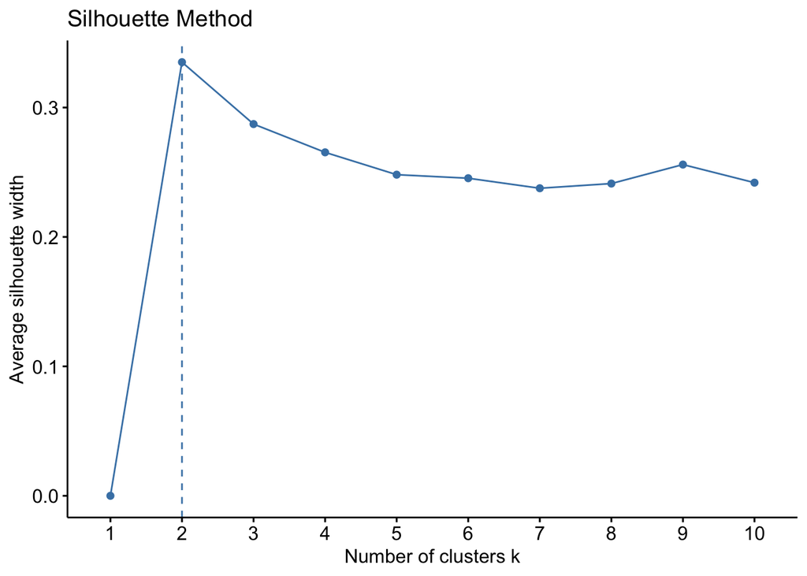

```r
#Customer segmentation using k-means or clustering
# Prep Data
customer_features <- sales_full[, .(
  total_spent = sum(TotalPrice, na.rm = TRUE),
  avg_spent = mean(TotalPrice, na.rm = TRUE),
  total_items = sum(Quantity, na.rm = TRUE),
  num_orders = .N,
  unique_categories = uniqueN(CategoryID),
  unique_products = uniqueN(ProductID)
), by = CustomerID]
customer_features_scaled <- as.data.table(scale(customer_features[, -1]))  # drop CustomerID
customer_features_scaled[, CustomerID := customer_features$CustomerID]

#  Subset for PCA & K-means
set.seed(123)
subset_data <- customer_features_scaled[sample(.N, min(10000, .N))]  # Take max 10K rows
features_only <- subset_data[, !("CustomerID"), with = FALSE]

# Run PCA
pca <- prcomp(features_only, center = TRUE, scale. = TRUE)

# Find #  of clusters
fviz_nbclust(features_only, kmeans, method = "silhouette") +
  labs(title = "Silhouette Method")
```

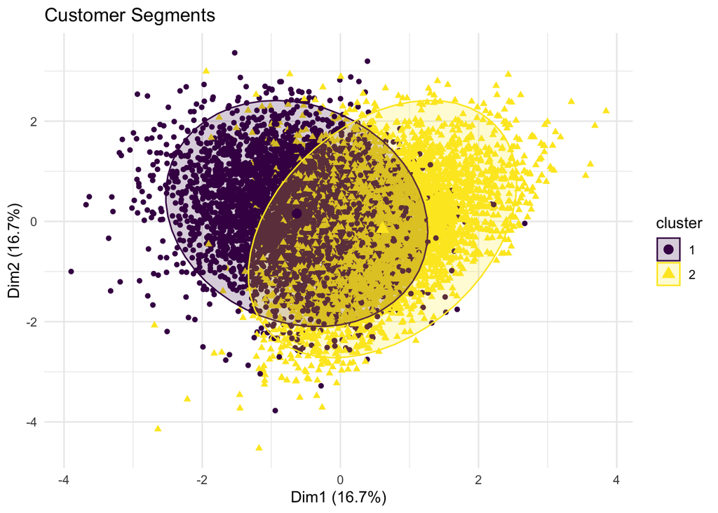

```r
# Run K-means
set.seed(123)
k <- 2  # Adjust based on elbow/silhouette
kmeans_result <- kmeans(pca$x[, 1:4], centers = k)

# Attach clusters to data
subset_data[, cluster := factor(kmeans_result$cluster)]

# Plot PCA clusters
viridis_colors <- viridis(k)
fviz_cluster(
  list(data = pca$x, cluster = kmeans_result$cluster),
  geom = "point",
  ellipse.type = "norm",
  main = "Customer Segments",
  palette = viridis_colors) +
  theme_minimal()
```

```r
# Summarize
subset_data[, cluster := factor(kmeans_result$cluster)]
summary_by_cluster <- subset_data[, lapply(.SD, mean), by = cluster]
print(summary_by_cluster)
```

[output not shown]

# Conclusion

Going forward and looking to increase sales:

- Possibly invest more money in Produce, Grain and Beverage categories as these are the most profitable
  - This could be through selling more unique products in these categories, or having more of these products in stock
- Either decrease investments in Poultry, Shellfish and Cereal or increase advertising and marketability of these items to increase sales in these categories
- Since basket size and high priced items can increase total amount spend, researching marketing techniques to customers to increase both of these
  - Placing high priced items that “go together” in the store to create a customer’s basket making it easier for them to easily purchase those items
- Employees effects sales, with those older and more tenured performing better
  - Researching ways to create better training programs at low cost may improve performance
  - High performing salespeople may indicate incentives through promotion or salary increases
- There are 2 customer groups:
  - The ideal customer: High spender, shop often, purchase multiple items, purchases across multiple unique categories and products
  - The less ideal customer: cost saver, shop rarely, purchase few items, purchases stay in limited categories and products
    - It’s important to understand both types of customers as both their sales matter and research more how to market to both of them to increase sales
- Looking at the current sales trend, without making any changes, we will likely see a dip in sales over the next few months in comparison to where sales has been sitting
  - This is based one what we have already seen, however with advertising and icnreased employee training tactics, this could change